# CYCLISTIC _bike_share_results

Charles

2024-11-12

##Setting up my environment

##Loading the packages

```r
library(lubridate)
```

```r
library(ggplot2)
library(readr)
```

```r
packageVersion("xfun")
```

```
## [1] '0.47'
```

```r
options(repos = c(CRAN = "https://cran.rstudio.com/"))
```

```r
install.packages("xfun", dependencies = TRUE)
```

##Importing the data ###Data tables source from two separate tables and the combine them together

```r
setwd("C:/Users/Charles/OneDrive/Desktop/statistics")
```

##Reading the csv tables

###trip data 2020

```r
library(readr)
TRIP_DATA_2020_ <- read_csv("TRIP_DATA_2020_.csv")
View(TRIP_DATA_2020_)
```

###trip data 2019

```r
library(readr)
TRIP_DATA_2019_ <- read_csv("TRIP DATA 2019_.csv")
View(TRIP_DATA_2019_)
```

###change the column format to be consistent

```r
TRIP_DATA_2020_$ride_length <-as.character(TRIP_DATA_2020_$ride_length)
```

```r
TRIP_DATA_2019_$ride_length <-as.character(TRIP_DATA_2019_$ride_length)
```

##combine the two tables rows ###Assign a vector name to the joined table

```r
library(dplyr)
Combined_data <- bind_rows(TRIP_DATA_2019_,TRIP_DATA_2020_)
```

##add combined columns ##Clean the data further ready for analysis

```r
Cleaned_data <- Combined_data %>%
  mutate(
    combined_user_type = coalesce(member_casual,usertype),
   combined_start_station_id = coalesce(start_station_id, from_station_id),
    combined_day_of_week = coalesce(`day_ of _week` ,day_of_week)
  )
```

##Select columns to aid us in analysis ###preparing data for analysis

```r
Analysis_data <- Cleaned_data %>%
  select(combined_user_type,trip_id,gender,birthyear,,combined_start_station_id,combined_day_of_week)
```

```r
 Analysis_data %>%
  group_by(combined_day_of_week) %>%
  summarize(num_trips = n())
```

```
## # A tibble: 7 × 2
##   combined_day_of_week num_trips
##                  <dbl>     <int>
## 1                    1     78849
## 2                    2    117177
## 3                    3    135966
## 4                    4    130325
## 5                    5    133043
## 6                    6    123710
## 7                    7     72886
```

##Exploration and visualization ###Explore the data more for analysis

####Usertype gender this helps us understand the genders of the bike share company users. N/A represents the data table that did not capture the genders but its still useful for our business task

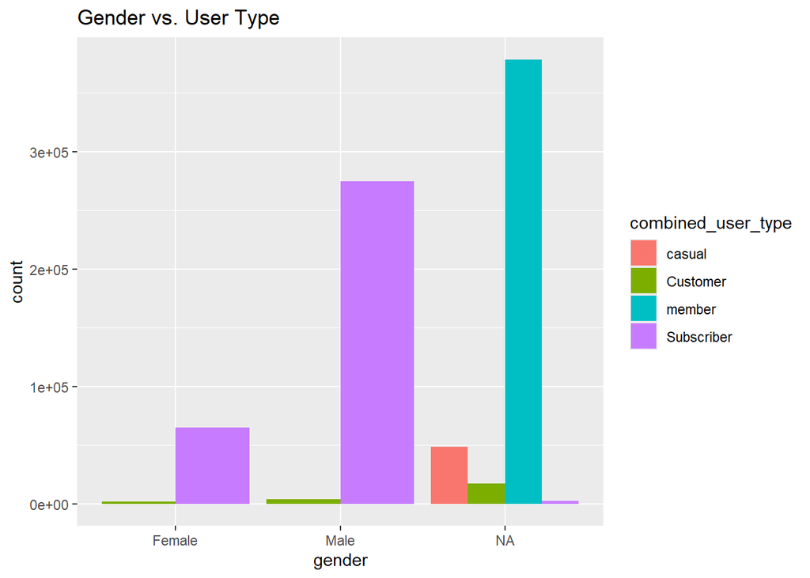

```r
ggplot(Analysis_data, aes(x = gender, fill = combined_user_type)) +
  geom_bar(position = "dodge") +
  labs(title = "Gender vs. User Type")
```

#### Birth Year vs. User Type

this helps us determine the age group of the highest members,customers as well as the lowest.

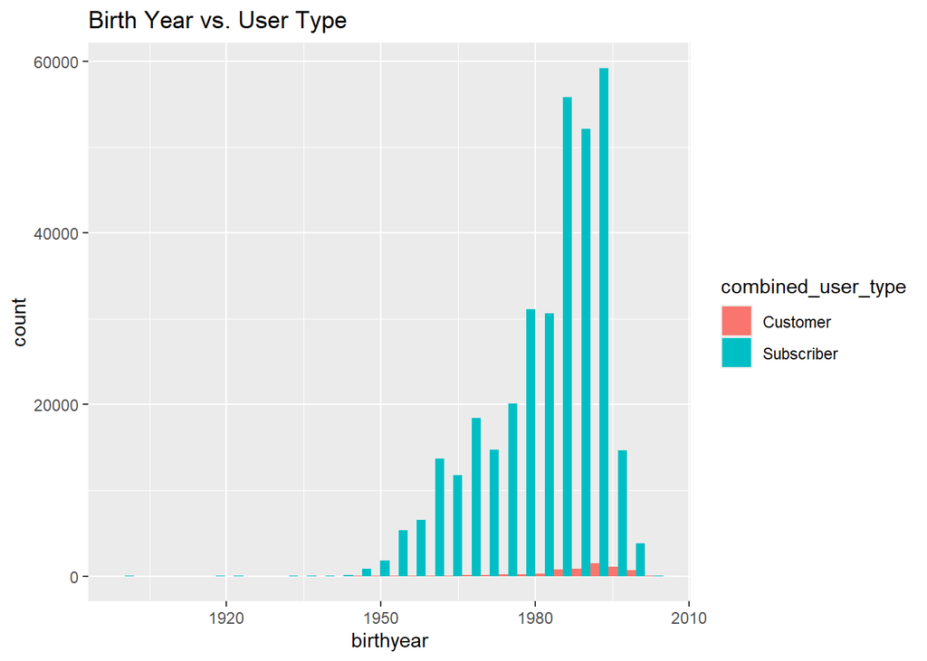

```r
ggplot(Analysis_data, aes(x = birthyear, fill = combined_user_type)) +
  geom_histogram(position = "dodge") +
  labs(title = "Birth Year vs. User Type")
```

#### Number of trips by Start Station/Usertype by start station

```r
 Analysis_data %>%
  group_by(combined_start_station_id) %>%
  summarize(num_trips = n())
```

```
## # A tibble: 612 × 2
##    combined_start_station_id num_trips
##                        <dbl>     <int>
##  1                         2       746
##  2                         3      2899
##  3                         4      1242
##  4                         5      1392
##  5                         6      1352
##  6                         7      1795
##  7                         9       118
##  8                        11        56
##  9                        12       123
## 10                        13      3074
## # ℹ 602 more rows
```

### Number of trips per start_station

###Add a filtered data frame

```r
Usertype_trips <- Analysis_data %>%
  group_by(combined_user_type) %>%
  summarize(num_trips = n())
```

###Visualization

```r
library(tidyr)
library(ggplot2)
```

####Usertype number of trips

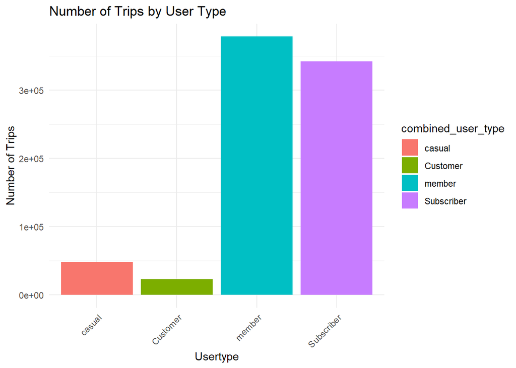

```r
ggplot(Usertype_trips, aes(x = combined_user_type, y = num_trips, fill = combined_user_type)) +
  geom_bar(stat = "identity", position = "dodge") +
  labs(title = "Number of Trips by User Type",
       x = "Usertype",
       y = "Number of Trips") +
  theme_minimal() +
  theme(axis.text.x = element_text(angle = 45, hjust = 1))
```

###Visualization ####Usertype total count in each start_station

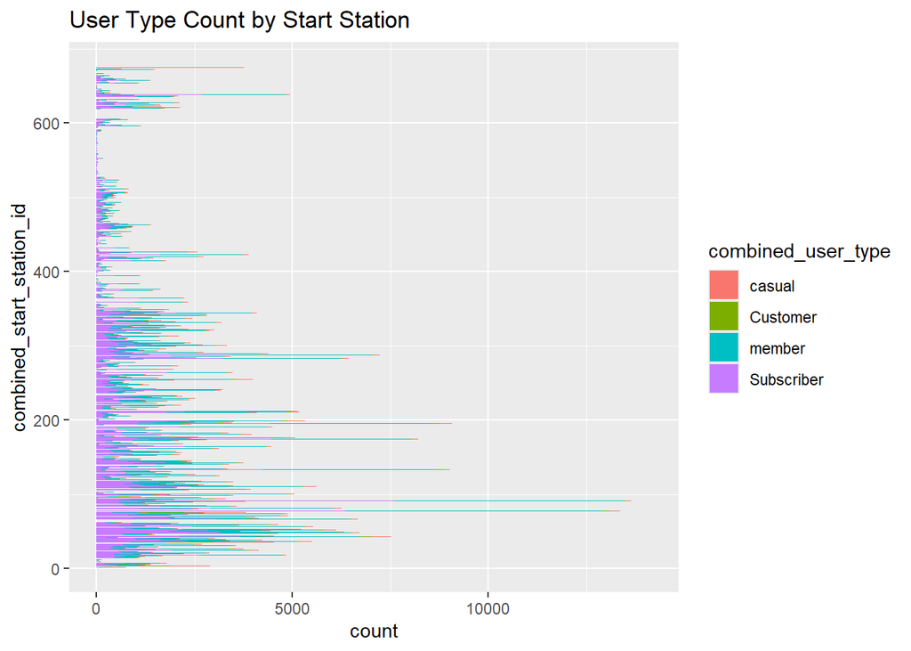

```r
ggplot(Analysis_data, aes(x = combined_start_station_id, fill = combined_user_type)) +
  geom_bar() +
  coord_flip() +
  labs(title = "User Type Count by Start Station")
```